# Dataton BC-2018

ADA Analytics

20 de octubre de 2018

```r
library(tidyverse)
```

## Objetivo

1. Implementar un modelo análitico para la categorarización de las transacciones provenientes del canal PSE basados en el comportamiento de transacciones de los clientes Bancolombia.
2. Proponer un modelo análitico para integrarse a un PFM para darle mayor valor agregado e incrementar el nivel de adopción de éstos.

## Lectura de datos

A continuación se carga la data que representa la muestra aleatoria de las transacciones de 37562 clientes de BC.

```r
load("df.comp.m.21102018.RData")
## La data se llama df.comp.m
```

La data de la muestra se renombra como *df.comp* para comodidad, ya que los algortimos iniciales que habiamos desarrollados llevaban este nombre de manera estandar.

```r
#Renombrando la data
df.comp <- df.comp.m
rm(df.comp.m) # removiendo la data de df.comp.m para mejorar espacio en la RAM.
```

## Análisis descriptivo de variables

### Valores perdidos

La siguiente función nos permite dar un vistazo rápido al nivel de valores perdidos en los datos.

```r
# Función resumen de valores perdidos.

prop.na <- function(dataframe) {
    m <- sapply(dataframe, function(x) {
        data.frame(
            nmiss=sum(is.na(x)),
            n=length(x),
            propnas=sum(is.na(x))/length(x)
        )
    })
    d <- data.frame(t(m))
    d <- sapply(d, unlist)
    d <- as.data.frame(d)
    d$variable <- row.names(d)
    row.names(d) <- NULL
    d <- cbind(d[ncol(d)],d[-ncol(d)])
    return(d[order(d$propnas,decreasing = TRUE), ])
}
```

Aplicando la función resumen de valores perdidos sobre la data de muestra.

```r
df.na <- prop.na(df.comp)
head(df.na)
```

```
##            variable   nmiss       n    propnas
## 8              ref3 1311497 1311497 1.00000000
## 7              ref2  562246 1311497 0.42870552
## 19    tipo_vivienda  544541 1311497 0.41520568
## 12         seg_str1   39208 1311497 0.02989561
## 13 nivel_academico1   39208 1311497 0.02989561
## 14    estado_civil1   39208 1311497 0.02989561
```

Al tener el número de valores perdidos de cada variable en la data de transacciones y personas, se puede observar que las variables ref3, ref2 y tipo_vivienda son las que presentan la mayor cantidad de valores perdidos. Incluso la variable referencia 3 esta completamente vacia, por lo que no aporta nada de información.

```r
df.na.1 <- df.na[order(df.na$nmiss,decreasing = T),]
require(pander)
pander(df.na.1)
```

|  | variable | nmiss | n | propnas |
| --- | --- | --- | --- | --- |
| **8** | ref3 | 1311497 | 1311497 | 1 |
| **7** | ref2 | 562246 | 1311497 | 0.4287 |
| **19** | tipo_vivienda | 544541 | 1311497 | 0.4152 |
| **12** | seg_str1 | 39208 | 1311497 | 0.0299 |
| **13** | nivel_academico1 | 39208 | 1311497 | 0.0299 |
| **14** | estado_civil1 | 39208 | 1311497 | 0.0299 |
| **15** | ingreso_rango1 | 39208 | 1311497 | 0.0299 |
| **16** | edad | 39208 | 1311497 | 0.0299 |
| **17** | genero1 | 39208 | 1311497 | 0.0299 |
| **18** | ocupacion1 | 39208 | 1311497 | 0.0299 |
| **6** | ref1 | 39058 | 1311497 | 0.02978 |
| **9** | sector | 1395 | 1311497 | 0.001064 |
| **10** | subsector | 1395 | 1311497 | 0.001064 |
| **11** | descripcion | 1395 | 1311497 | 0.001064 |
| **1** | id_trn_ach | 0 | 1311497 | 0 |
| **2** | id_cliente | 0 | 1311497 | 0 |
| **3** | fecha | 0 | 1311497 | 0 |
| **4** | hora | 0 | 1311497 | 0 |
| **5** | valor_trx | 0 | 1311497 | 0 |

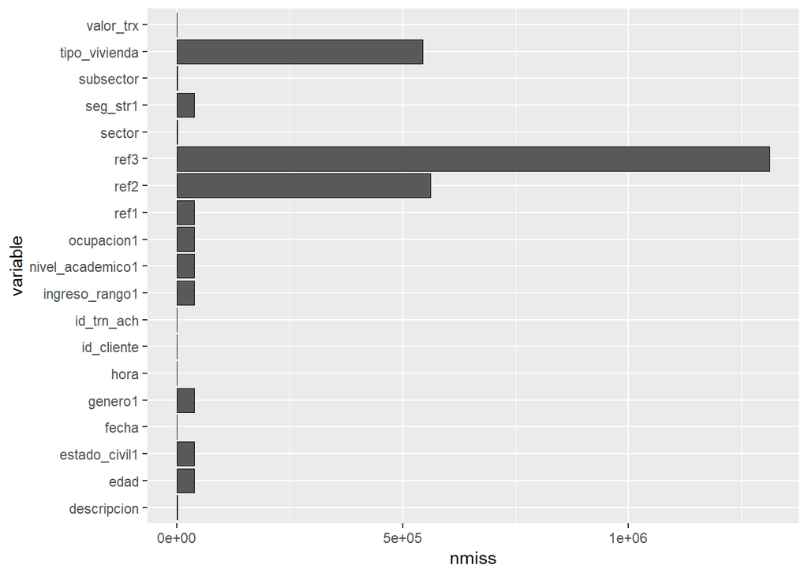

```r
## Gráfico de resumen de valores perdidos
gra.2<-ggplot(data = df.na.1, aes(x=variable, y=nmiss)) + geom_col(colour= "black", size = 0.2 ) +coord_flip()
gra.2
```

### Estadísticas descriptivas de las variables

#### Variable valor_trx

```r
## Estadísticos de resumen en R
summary(df.comp$valor_trx)
```

```
##      Min.   1st Qu.    Median      Mean   3rd Qu.      Max.
## 0.000e+00 5.208e+04 1.254e+05 3.735e+05 3.002e+05 1.362e+09
```

```r
## Número de valores perdidos
sum(is.na(df.comp$valor_trx))
```

```
## [1] 0
```

**Valores atipicos**

En el siguiente boxplot se puede apreciar una gran presencia de valores atípicos, inclusive son transacciones que superan los 100 millones de pesos, siendo valores bastante atípicos debido aque la plataforma de PSE a pesar de poseer opciones para modificar los montos o el número de transacciones que puede realizar diariamente por este canal.

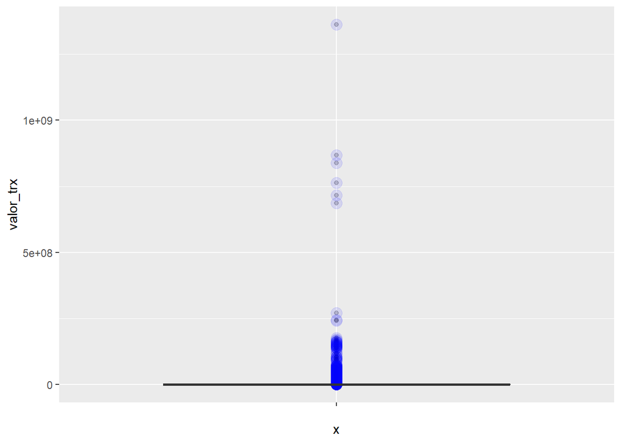

```r
# Boxplot agrupado por genero
library(Rmisc)
NotFancy <- function(l) {
 l <- format(l, scientific = FALSE)
 parse(text=l)
}

p1 <- ggplot(data = df.comp, aes(x="", y=valor_trx)) +
            scale_y_continuous(labels=NotFancy) +
            geom_point(alpha=0.2) +
            geom_boxplot(outlier.size=4, outlier.colour='blue', alpha=0.1)

plot(p1)
```

Una primria limpieza se realizó al filtrar la data donde el monto de la transacciones sea inferior a 50 millones de pesos. Sin embargo esto no resulta muy poco efectivo ya que se sigue evidenciando un gran volumen de valores atípicos, y esto también distrociona los valores atípicos inderiores.

```r
df.comp1 <- df.comp[df.comp$valor_trx<= 50000000,]
```

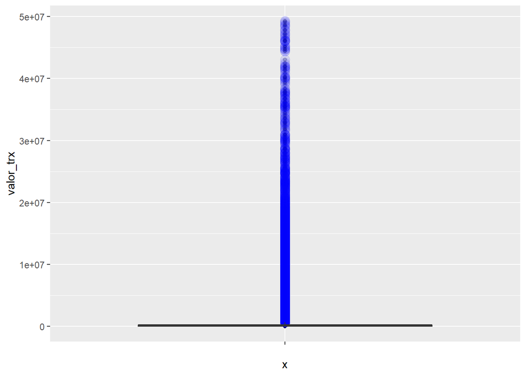

```r
# Boxplot
p2 <- ggplot(data = df.comp1, aes(x="", y=valor_trx)) +
            scale_y_continuous(labels=NotFancy) +
            geom_point(alpha=0.2) +
            geom_boxplot(outlier.size=4, outlier.colour='blue', alpha=0.1)

plot(p2)
```

Por lo cuál se decide filtrar esta variable a montos cercanos al limite propuesto por PSE por defecto ($1.200.000 por transacción diaria) considerandose el valor de 1.2 millones.

```r
df.comp2 <- df.comp[df.comp$valor_trx<= 1200000,]
```

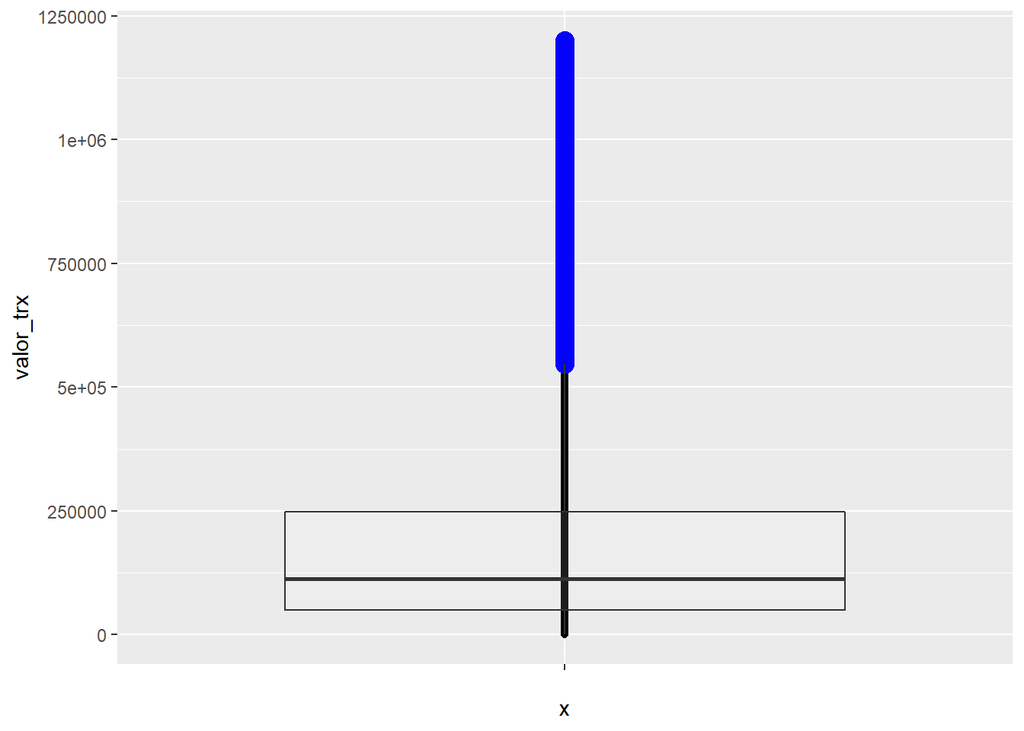

```r
# Boxplot
p3 <- ggplot(data = df.comp2, aes(x=" ", y=valor_trx)) +
            scale_y_continuous(labels=NotFancy) +
            geom_point(alpha=0.2) +
            geom_boxplot(outlier.size=4, outlier.colour='blue', alpha=0.1)

plot(p3)
```

```r
outlier_values <- boxplot.stats(df.comp2$valor_trx)$out  # outlier values
head(outlier_values)
```

```
## [1]  903752.3  998112.2  987966.2  753567.1  849284.4 1027011.7
```

**Respaldando la data filtrada**

```r
# Guardando el DataFrame como  RData format
save(df.comp2, file = "df.comp.filtrada.RData")
```

```r
## Renombrando la data
df.comp <- df.comp2
```

### Sector del ente juridico o natural por donde se emplea PSE.

Respecto a la variable Sector de la empresa por donde se emplea el canal de PSE, los datos indican que se tiene muy poca información de ellos con una categoria “”, que es indicativo de desconocer la información, que supera el 65%. Mientras que la poca información que se tiene de estas empresas se centra principalmente en *MEDIOS DE COMUNICACION*, *SERVICIOS FINANCIEROS*, *RECURSOS NATURALES* y *SERVICIOS NO FINANCIEROS*.

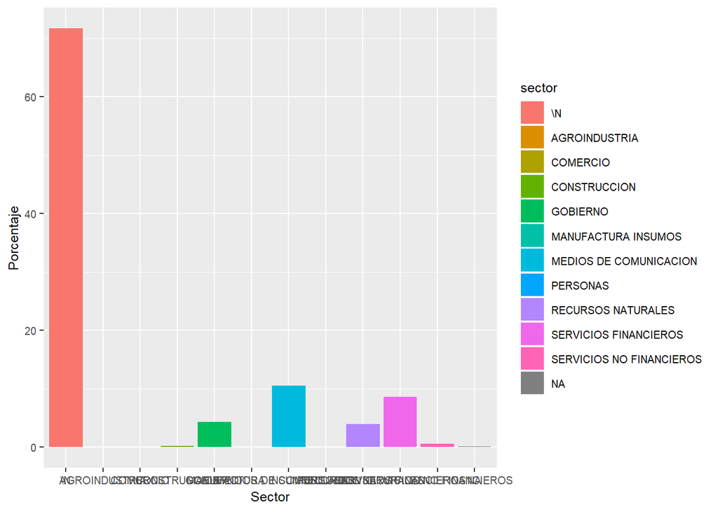

```r
## Grafico de barras con ggplot2
ggplot(df.comp, aes(x =sector,y=(..count.. *100)/sum(..count..),fill=sector)) + geom_bar()+ylab("Porcentaje")+xlab("Sector")+theme(text = element_text(size=9.5))
```

### Segmentación Estructural de los clientes por los Ingresos y su Tamaño Comercial.

Para la variable segmentación estructural, la información que se tiene indica que los mayores ingresos son los reportados por los cliente del grupo *EMPRENDEDOR*, que supera el 40%, seguido por los clientes *PREFERENCIAL* y *PERSONAL*. Para los clientes del grupo *Personal Plus* no se tiene información.

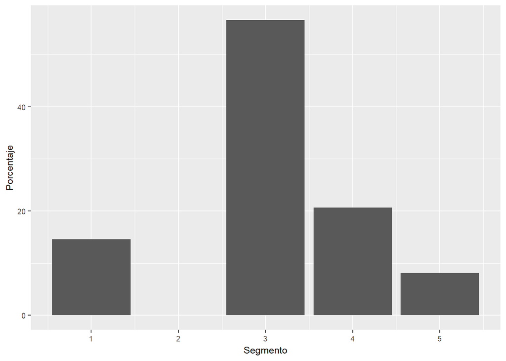

```r
## Grafico de barras con ggplot2
ggplot(df.comp, aes(x =seg_str1,y=(..count.. *100)/sum(..count..),fill=seg_str1)) + geom_bar()+ylab("Porcentaje")+xlab("Segmento")+theme(text = element_text(size=9.5))
```

### Oupación de los clientes.

Respecto a la ocupacion de los clientes, la data indica que se tiene información referente a más de un 60% de los clientes de Bancolombia que son *SOCIOS O EMPLEADOS*.

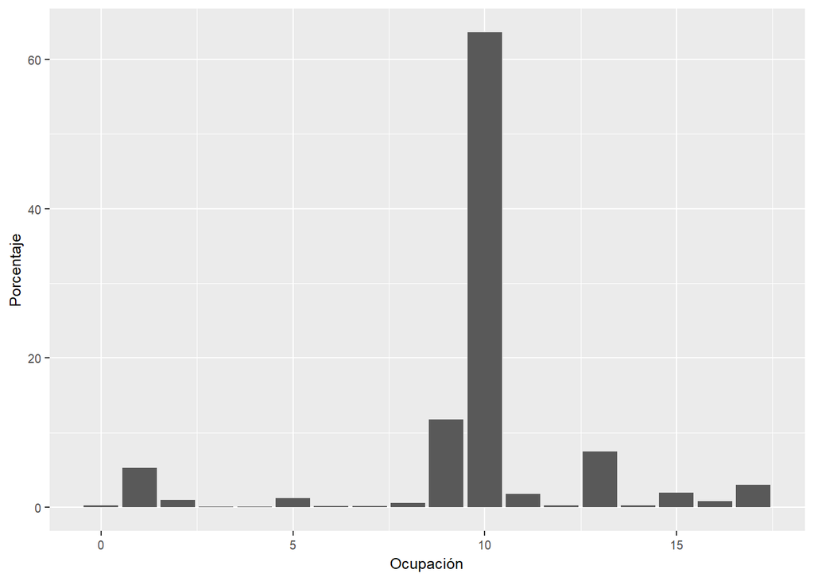

```r
## Grafico de barras con ggplot2
ggplot(df.comp, aes(x =ocupacion1,y=(..count.. *100)/sum(..count..),fill=ocupacion1)) + geom_bar()+ylab("Porcentaje")+xlab("Ocupación")+theme(text = element_text(size=9.5))
```

### Tipo de Vivienda.

Para la variable Tipo de Vivienda se tiene muy poca información ya que existe más de un 40% de valores faltantes, que es indicativo de desconocer el tipo de vivienda de los clientes. De la poca información que se tiene más del 30% de los clientes poseen vivienda del tipo *FAMILIAR* y más de un 10% de los clientes tienen vivienda *PROPIA*.

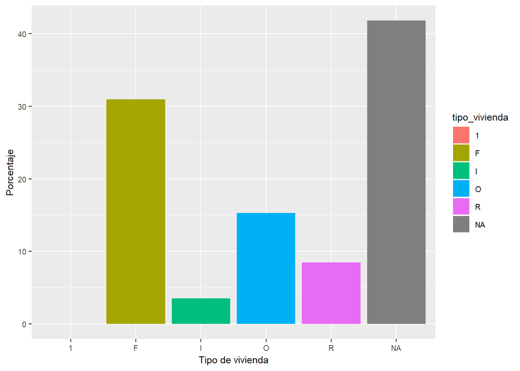

```r
## Grafico de barras con ggplot2
ggplot(df.comp, aes(x =tipo_vivienda,y=(..count.. *100)/sum(..count..),fill=tipo_vivienda)) + geom_bar()+ylab("Porcentaje")+xlab("Tipo de vivienda")+theme(text = element_text(size=9.5))
```

### Nivel Academico.

Respecto a la variable Nivel Academico se tiene que en la data que más de la mitad de los clientes tienen una formación *UNIVERSITARIA*, son muy pocos los clientes que no tienen ningún nivel academico.

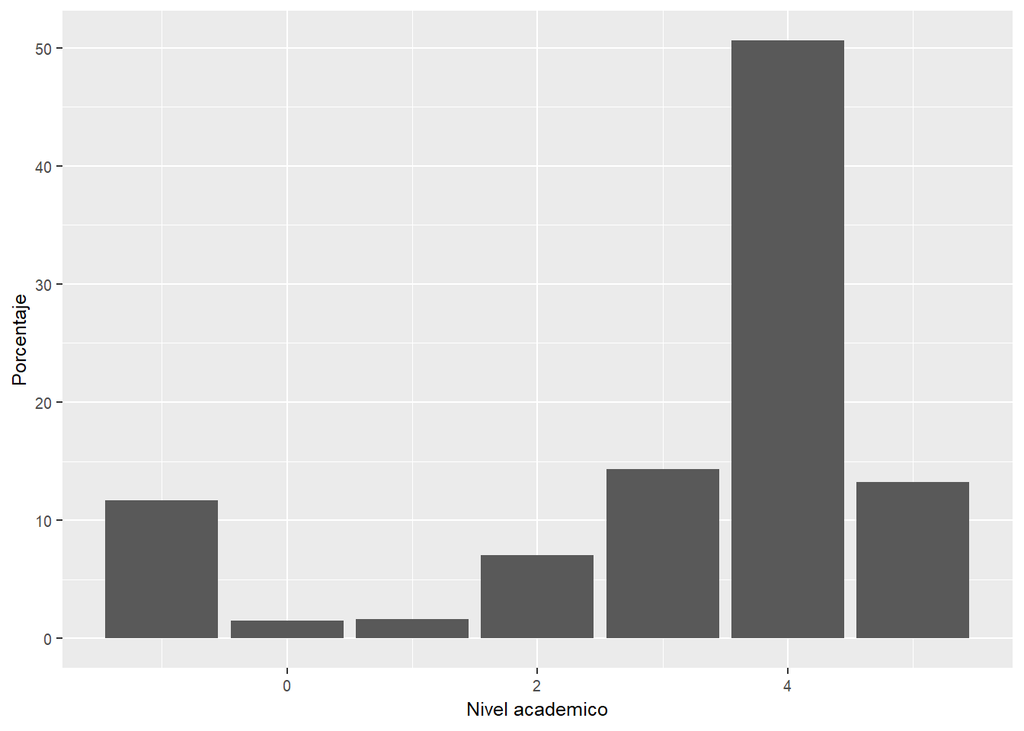

```r
## Grafico de barras con ggplot2
ggplot(df.comp, aes(x =nivel_academico1,y=(..count.. *100)/sum(..count..),fill=nivel_academico1)) + geom_bar()+ylab("Porcentaje")+xlab("Nivel academico")+theme(text = element_text(size=9.5))
```

### Estado Civil

De la información obtenida para la variable Estado Civil se tiene que casi la mitad de los clientes son *SOLTEROS*, y que un 30% son *CASADOS* y el 20% restantes de los clientes son *DIVORCIADO*,*VIUDO*,*DESCONOCCE*,*OTRO* o *NO INFORMA*.

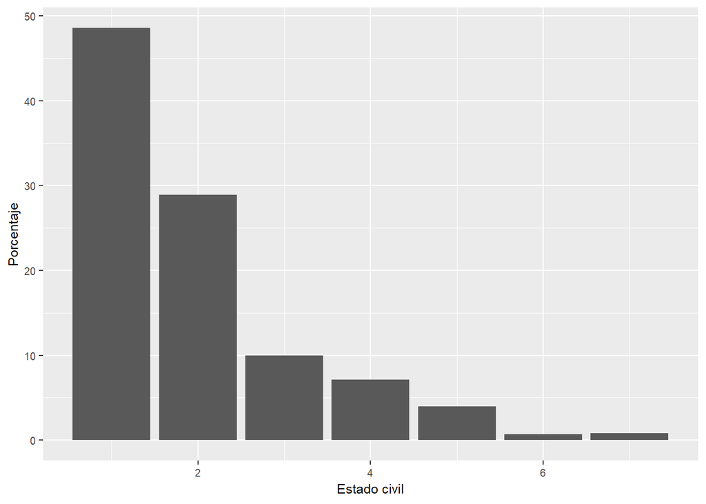

```r
## Grafico de barras con ggplot2
ggplot(df.comp, aes(x =estado_civil1,y=(..count.. *100)/sum(..count..),fill=estado_civil1)) + geom_bar()+ylab("Porcentaje")+xlab("Estado civil")+theme(text = element_text(size=9.5))
```

### Variable genero

Para la variable Genero se tiene que de la información total obtenida en la muestra de los clientes de Bancolombia se encuentran divididos equitativamente en clientes del Genero *Femenino* (0) y *Masculino*(1), siendo sólo por un pequeño porcentaje superior los clientes del Genero *Femenino*.

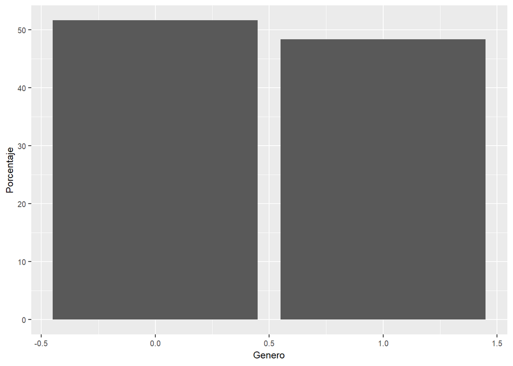

```r
## Grafico de barras con ggplot2
ggplot(df.comp, aes(x =genero1,y=(..count.. *100)/sum(..count..),fill=genero1)) + geom_bar()+ylab("Porcentaje")+xlab("Genero")+theme(text = element_text(size=9.5))
```

### Rango de Ingresos.

Respecto a la variable Rango de Ingresos se tiene que aproximadamente más del 20% de los clientes poseen ingresos de entre *1.1 a 2.2 MM*, más de un 15% de los clientes tienen Ingresos de entre *5.5 a 6.6. MM*. En general se tiene que el Mayor Porcentaje de los clientes tienen buenos Ingresos.

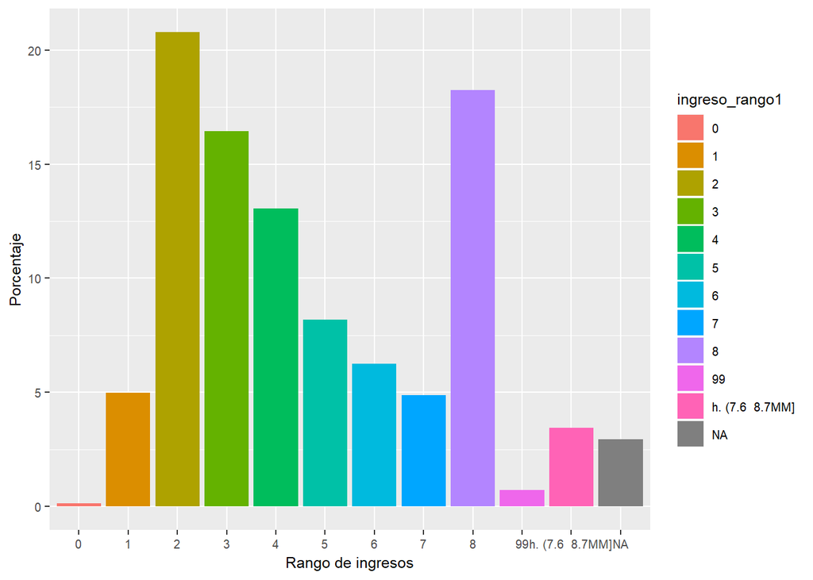

```r
## Grafico de barras con ggplot2
ggplot(df.comp, aes(x =ingreso_rango1,y=(..count.. *100)/sum(..count..),fill=ingreso_rango1)) + geom_bar()+ylab("Porcentaje")+xlab("Rango de ingresos")+theme(text = element_text(size=9.5))
```

## Text Mining

Como una primera aproximación al uso de la información contenida en las variables *ref1,ref2 y descripción*, nos apoyaremos en Texmining.

> **La minería de texto** o text mining se engloba dentro de las técnicas y modelos de minería de datos.Donde se empplea el análisis matemático para deducir patrones y tendencias que existen entre las palabras, patrones que no pueden detectarse mediante una exploración tradicional de los datos porque las relaciones son demasiado complejas o por el volumen de datos que se maneja.

> **Nota:** No se emplea la variable ref3, debido a que esta no posee muy poca o ninguna información.

Y dado que en la minería de texto obtenemos información nueva a partir de grandes cantidades de texto, en la que la información suele estar no estructurada. en esta sección nos enfocamos por entender las palabras claves más usadas en las transacciones y como estas nos pueden aportar información de gran valor que es necesaria para el modelo de separación de las distintas categorias.

### Limpieza de texto

El proceso de limpieza de texto, dentro del ámbito de text mining, consiste en eliminar del texto todo aquello que no aporte información sobre su temática, estructura o contenido. No existe una única forma de hacerlo, depende en gran medida de la finalidad del análisis y de la fuente de la que proceda el texto.

La finalidad de esta limpieza es poder Tokenizar de forma más optima el texto.

> Tokenizar un texto consiste en dividir el texto en las unidades que lo conforman, entendiendo por unidad el elemento más sencillo con significado propio para el análisis en cuestión, en este caso, las palabras.

Existen múltiples librerías que automatizan en gran medida la limpieza y tokenización de texto, por ejemplo, **tokenizers** o **quanteda**. Sin embargo, estas librerias se orientan principalmente a especializarse en textos en ingles, por lo debemos realizar un proceso para implemento una función que se adapte al español, si bien puede estar menos optimizada, es más transparente. Definir una función que contenga cada uno de los pasos de limpieza tiene la ventaja de poder adaptarse fácilmente dependiendo del tipo de texto analizado.

```r
# Librerias
library(knitr)
library(stringr)
library(NLP)
library(tm)

dataCleaner<-function(text){

  cleanText <- tolower(text)
  cleanText <- removePunctuation(cleanText)
  cleanText <- removeNumbers(cleanText)
  cleanText <- str_replace_all(cleanText, "[^[:alnum:]]", " ")
  cleanText <- str_replace_all(cleanText, "_", " ")
  cleanText <- str_replace_all(cleanText, "na"," ")
  cleanText <- str_replace_all(cleanText, "cc", " ")
  cleanText <- stripWhitespace(cleanText)
  #cleanText <- stemDocument(cleanText, language="spanish")


  return(cleanText)
}
```

Se realizo una limpieza de los valores de tipo texto de la data. Esta limpieza incluye:

```r
# aplicando la función de limpieza de datos
df.comp$ref1=dataCleaner(df.comp$ref1)
df.comp$ref2=dataCleaner(df.comp$ref2)
df.comp$ref3=dataCleaner(df.comp$ref3)
df.comp <- transform(df.comp, text = paste(ref1,ref2))
```

El siguiente paso es transformar el texto en una estructuración de tipo *corpus*, con el cual se sacarán las palabras más frecuentes empleadas por los agentes que emplean el canal PSE.

```r
library(ANLP)
datacorpus<- paste(df.comp$text)
datacorpus<- cleanTextData(datacorpus)
#ngramModel1 <- generateTDM(datacorpus,1)
#ngramModel2 <- generateTDM(datacorpus,2)
#ngramModel3 <- generateTDM(datacorpus,3)
#ngramModel4 <- generateTDM(datacorpus,4)
```

Una vez el texto este estructurado de forma correcta, se procede a obtener los unigramas, bigramas y trigramas a explorar para la ditribución de las frecuencias en el uso de las palabras.

```r
corpus2 <- VCorpus(VectorSource(datacorpus))

# Prepare n-gram frequencies
getFreq <- function(tdm) {
  freq <- sort(rowSums(as.matrix(rollup(tdm, 2, FUN = sum)), na.rm = T), decreasing = TRUE)
  return(data.frame(word = names(freq), freq = freq))
}

unigram <- function(x) NGramTokenizer(x, Weka_control(min = 1, max = 1))
bigram <- function(x) NGramTokenizer(x, Weka_control(min = 2, max = 2))
trigram <- function(x) NGramTokenizer(x, Weka_control(min = 3, max = 3))
quadgram <- function(x) NGramTokenizer(x, Weka_control(min = 4, max = 4))
pentagram <- function(x) NGramTokenizer(x, Weka_control(min = 5, max = 5))
hexagram <- function(x) NGramTokenizer(x, Weka_control(min = 6, max = 6))


library(slam)
# Get frequencies of most common n-grams in data sample
#1gram frequency
freq1 <- getFreq(TermDocumentMatrix(corpus2, control = list(tokenize = unigram))) #with stop words
#freq1 <- getFreq(removeSparseTerms(TermDocumentMatrix(unicorpus), 0.999)) #without stop words
#2gram frequency
freq2 <- getFreq(TermDocumentMatrix(corpus2, control = list(tokenize = bigram))) #with stop words
#freq2 <- getFreq(TermDocumentMatrix(unicorpus, control = list(tokenize = bigram))) #without stop words
#3gram frequency
freq3 <- getFreq(TermDocumentMatrix(corpus2, control = list(tokenize = trigram)))
#4gram frequency
freq4 <- getFreq(TermDocumentMatrix(corpus2, control = list(tokenize = quadgram)))
#5gram frequency
freq5 <- getFreq(TermDocumentMatrix(corpus2, control = list(tokenize = pentagram)))
#6gram frequency
#freq6 <- getFreq(TermDocumentMatrix(corpus, control = list(tokenize = hexagram)))
#freq4_2 <- getFreq(TermDocumentMatrix(corpus2, control = list(tokenize = quadgram)))

modelsList = list(freq5,freq4,freq3,freq2,freq1) #y luego quedarse con las frases que tienen mas de 1 frecuencia
```

```r
######################################################################
# Plot n-grams
######################################################################

library(ggplot2)
library(gridExtra)

plot1<-ggplot(freq1[1:10,], aes(x = reorder(word, freq), y = freq )) +
  geom_bar(stat = "identity", color = "black", fill = "grey") +
  coord_flip() +
  labs(title = "Frequency 1gram\n", x = "1gram\n", y = "Frequency\n")

plot2<-ggplot(freq2[1:10,], aes(x = reorder(word, freq), y = freq )) +
  geom_bar(stat = "identity", color = "black", fill = "grey") +
  coord_flip() +
  labs(title = "Frequency 2gram\n", x = "2gram\n", y = "Frequency\n")

plot3<-ggplot(freq3[1:10,], aes(x = reorder(word, freq), y = freq )) +
  geom_bar(stat = "identity", color = "black", fill = "grey") +
 coord_flip() +
  labs(title = "Frequency 3gram\n", x = "3gram\n", y = "Frequency\n")
plot4<-ggplot(freq4[1:10,], aes(x = reorder(word, freq), y = freq )) +
  geom_bar(stat = "identity", color = "black", fill = "grey") +
  coord_flip() +
  labs(title = "Frequency 3gram\n", x = "3gram\n", y = "Frequency\n")

##grid.arrange( plot1, plot2,plot3,plot4, ncol=3)
```

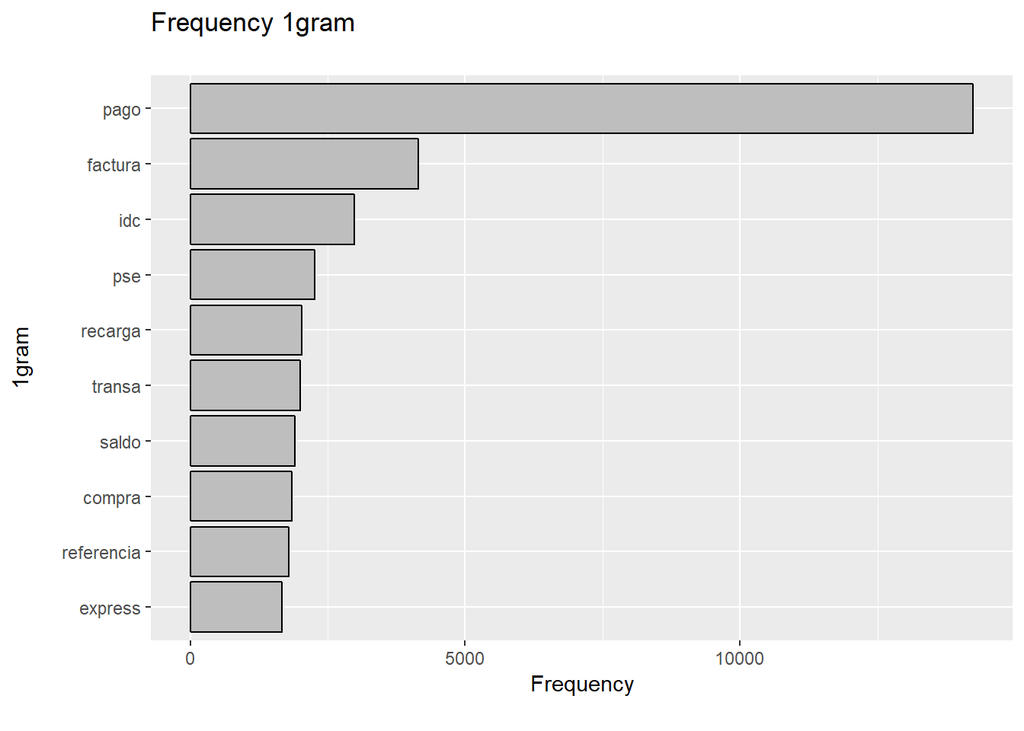

```r
grid.arrange(plot1)
```

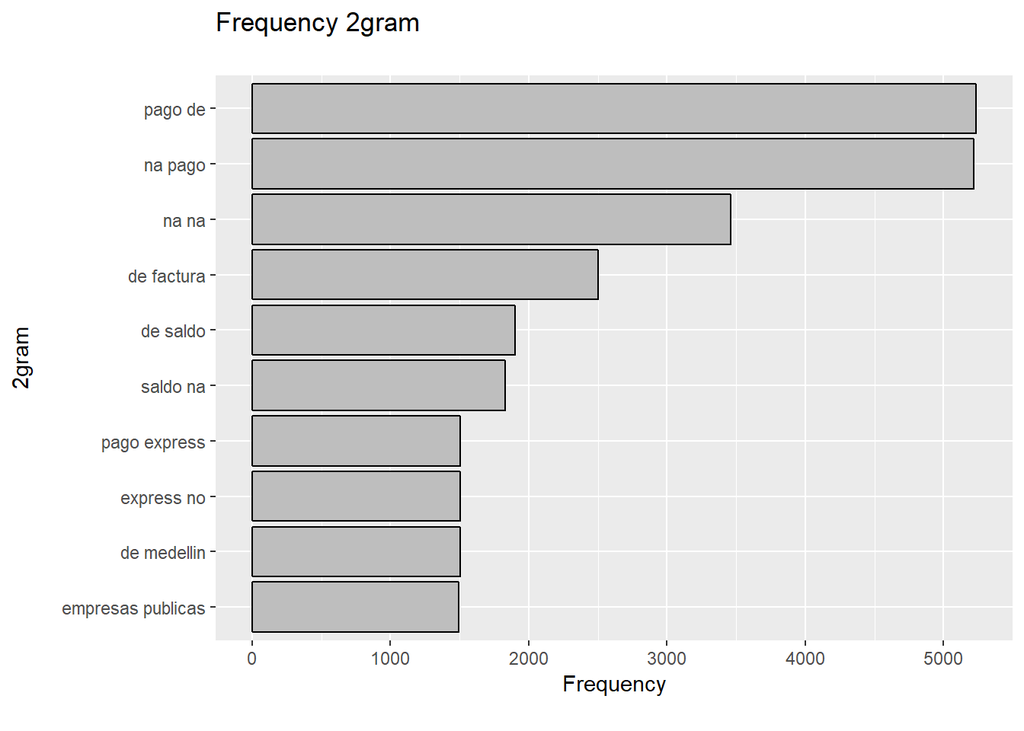

```r
grid.arrange( plot2)
```

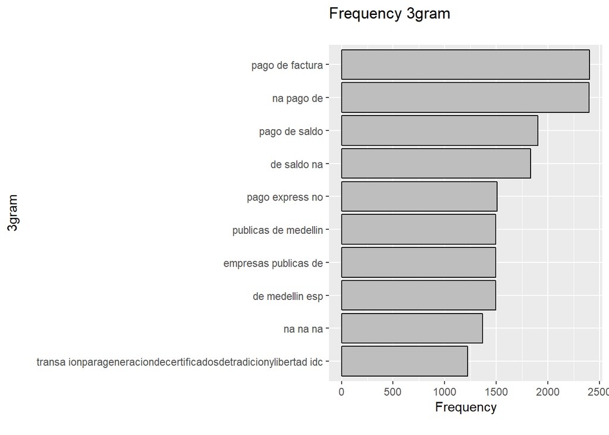

```r
grid.arrange(plot3)
```

A continuación se presenta un resumen más completo de las palabras o combinación de ellas que suelen presentarse con mayor frecuencia.

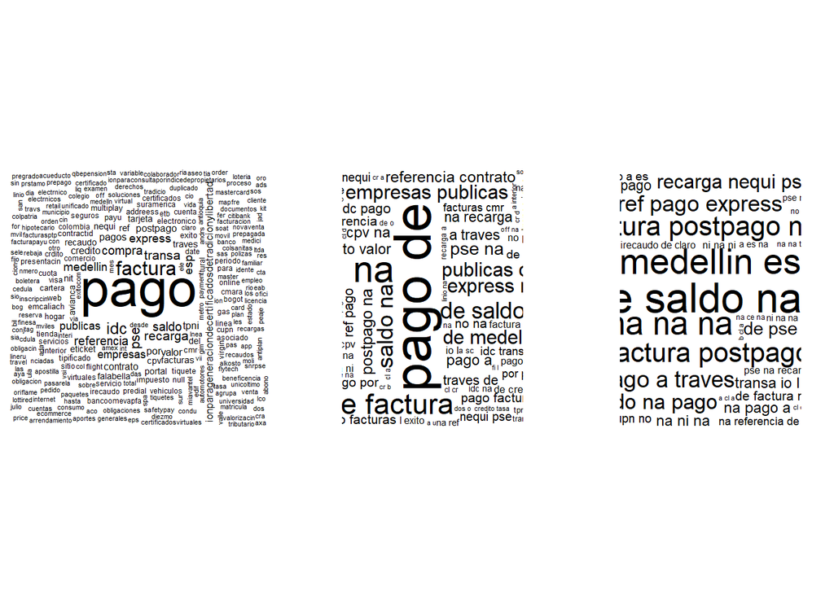

```r
######################################################################
# cloud n-grams
######################################################################
library(wordcloud)
par(mfrow=c(1,3))
wordcloud(words=freq1$word, freq=freq1$freq, random.order=FALSE);
#title("1-grams Word Cloud without stop words")

wordcloud(words=freq2$word, freq=freq2$freq, random.order=FALSE);
#title("2-grams Word Cloud without stop words")

wordcloud(words=freq3$word, freq=freq3$freq, random.order=FALSE);
```

```r
#title("3-grams Word Cloud with stop word ")
```

## Text Mining y Analísis Cluster

Ya con un análisis preliminar de text mining, lograndose identificar palabras o combinaciones de estas que brindan información del tipo de transacción y dan sentido a una categoria a conformar, se procede a generar una data que contemple el uso de las palabras más frecuentes para emlear, para posteriormente generar cluster que representen las categorias de las transacciones.

```r
## Librerias.
library(tm)         # text mining
library(RWeka)      # collection of machine learning algorithms
library(dendextend) # Dendogram (hierarchical clustering)
library(cluster)    # clustering
library(clValid)    # Calculating Dunn index
library(quanteda)   # Text Mining
library(tidytext)   # Text Mining and dplyr
```

```r
## Consultado la data de text
df.comp1 <- df.comp %>% select(id_trn_ach,ref1)
text.ref1 <- df.comp1 %>% unnest_tokens(word, ref1)
```

Y como en el análisis anterior solo se realizo una inspección de las palabras empleadas, existen palabras que no generan ningún valor, las cuales se eliminarán en el siguiente paso.

```r
## Vector de palabras a quitar (stopwords)
custom_stop_words <-bind_rows(data_frame(word = c("referencia","pago","pagos","traves", "a","al","enero","febrero","marzo","abril","mayo","junio","julio","agoosto","septiembre","octubre","noviembre","diciembre"),
                                          lexicon = c("custom")),data_frame(word = tm::stopwords("spanish"),lexicon = "custom"))
```

```r
## Limpiando los datos de las palabras stopwords
tidy_trans <- text.ref1  %>%
  anti_join(custom_stop_words)
```

Pero aún cuando se emplean librerias o listas de stop_words, se debe estar muy pendientes de que no se esten yendo terminos o frases sin sentido, o que poco pudiesen beneficiar el modelo.

```r
t<- as.data.frame(table(tidy_trans$word))
head(t)
```

```
##   Var1 Freq
## 1    ª    1
## 2    á    1
## 3    â    5
## 4    ã    6
## 5   aa  336
## 6   aã   19
```

Por lo que se hace un pre-filtrado con las palabras que tengan 5000 o más repeticiones, más que todo por los pocos recursos de procesamiento con los que contamos actualmente.

```r
t1 <-t[t$Freq>=5000,]
colnames(t1)<-c("word","Freq")
head(t1,n=15)
```

```
##              word  Freq
## 589      addreess 15342
## 1643         amex  5963
## 2447     asociado  6451
## 2765      avianca 10202
## 3143        banco  5357
## 4393       bogotá  9251
## 5355       cámara  9483
## 5677      cartera 15281
## 6200 certificados  7826
## 6761           cl 11940
## 6776        claro  5046
## 6935          cmr 14667
## 7118     colombia  7370
## 7183     comercio 11280
## 7302       compra 58933
```

```r
## Seleccionando las palabras de ínteres
tidy_trans1 <- inner_join(tidy_trans,t1)
##  Quitando la variable frecuencia de la data
tidy_trans1 <-tidy_trans1[,-3]
```

Ahora, la siguiente función convierte cada palabra en un booleano.

```r
## install.packages("fastDummies")
results <- fastDummies::dummy_cols(tidy_trans1, select_columns = "word")
```

Lo siguiente es quitar los duplicados que la lista de palabras dejaba, por lo que se hace una suma por transacción en cada una de las palabras encontradas.

```r
results1<- results %>% select(-word)

results2 <- results1 %>% group_by(id_trn_ach) %>% summarise_all(funs(sum))
```

```r
#Removiendo las tadas que no se usaran
rm(results1,results)
```

**Observación:** Se pudiese pensar que para compensar que no se pueden contar con todas las palabras con alta frecuencia usada en los comentarios, se procede a buscar las combinaciones por dos palabras que sean de mayor frecuencia en los comentarios de texto, sin embaro los unigramas en forma booleana compensan hasta cierto punto el no usar los bigramas, dado que recogen la firomación.

### Unificando las datas de texto y la data de transacciones

```r
df.clus <- left_join(df.comp,results2, by="id_trn_ach")
dim(df.clus)
```

```
## [1] 1232139     107
```

AHora se pueden también aprovechar los datos que arroja la fecha de la transacción. Especialmente el día, porque tenemos la hipotesis de que existen transacciones que se suelen reslizar en ciertas ventanas de tiempo que tienen a ser recurrentes como lo es el pago de servicios públicos o el pago del servicio teléfonico.

```r
library(lubridate)
df.clus$dia <- day(df.clus$fecha) #Calculando el día del mes
```

### Imputando a cero las variables Booleanas

La siguiente función esta diseñada para imputar por cero los valores perdidos *NA*.

```r
## Función para sustituir el Na por un valor de cero
imputacero <- function(x){
    y <- ifelse(is.na(x),0,x)
}
```

```r
## Aplicando la función imputa cero
columnas <- 21:108 ## Posición de columnas a imputar
df.clus[,columnas]<- lapply(df.clus[,columnas],imputacero)
```

### Recodificando las variables faltantes

```r
## Recodificando las variables categorias a numericas
library(car)
df.clus$sector1 <- ifelse(df.clus$sector=="\\N",-99, ifelse(is.na(df.clus$sector),-99,ifelse(df.clus$sector=="AGROINDUSTRIA",1,ifelse(df.clus$sector=='COMERCIO',2, ifelse(df.clus$sector=='CONSTRUCCION',3,ifelse(df.clus$sector=='GOBIERNO',4,ifelse(df.clus$sector=='MANUFACTURA INSUMOS',5,ifelse(df.clus$sector=='MEDIOS DE COMUNICACION', 6,ifelse(df.clus$sector=='PERSONAS',7,ifelse(df.clus$sector=='RECURSOS NATURALES',8,ifelse(df.clus$sector=='SERVICIOS FINANCIEROS',9,ifelse(df.clus$sector=='SERVICIOS NO FINANCIEROS',10,-99))))))))))))

df.clus$subsector <- ifelse(df.clus$subsector == "\\N","Sin_info", ifelse(is.na(df.clus$subsector),"Sin_info",df.clus$subsector))
```

```r
## Codificando la variable tipo_vivienda
df.clus$tipo_vivienda1 <- ifelse(df.clus$tipo_vivienda =="1",-99,ifelse(df.clus$tipo_vivienda =="F",1,ifelse(df.clus$tipo_vivienda =="A",2,ifelse(df.clus$tipo_vivienda =="R",2,ifelse(df.clus$tipo_vivienda =="I",10,ifelse(df.clus$tipo_vivienda =="P",3,ifelse(df.clus$tipo_vivienda =="0",3,-99)))))))
```

```r
## Volviendo dummys las variables de subsector
df.clus1 <-fastDummies::dummy_cols(df.clus, select_columns = c("subsector"))
```

### Cluster con CLARA

```r
# respaldando la variable id_trn_ach
rownames(df.clus1) <- df.clus1$id_trn_ach
```

Ahora se seleccionan solo las variables numericas o seudonumericas(recodificadas) de la data para realizar los Cluster.

```r
# seleccionando variables númericas
df.clara <- na.omit(df.clus1[,c(5,12:18,21:153)])
```

Aunque en este punto se necesita de una gran cantidad de memoria del computador, por lo que se corrio previamente el algoritmo de CLARA, para poder generar el reporte.

```r
# Compute CLARA
#clara.res <- clara(df.clara, 15, samples = 150, pamLike = TRUE)
#save(clara.res, file = "mode_clara.rda")
#load(file = "mode_clara.rda")
```

```r
library(factoextra)
```

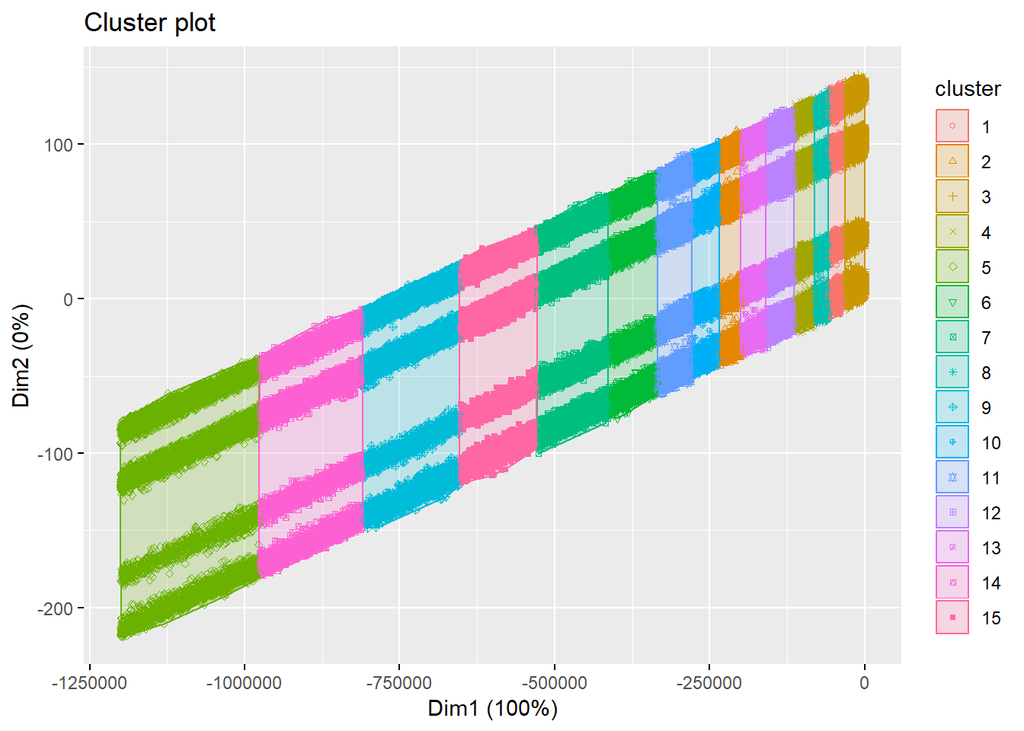

```r
# Cluster plot
#plot.clara <-fviz_cluster(clara.res, stand = F,geom = "point",  pointsize = 1)
#save(plot.clara, file = "plot_clara.rda")
load(file = "plot_clara.rda")
print(plot.clara)
```

Ahora, respaldamos la data con los cluster calculados, para posteriormente darle un sentido a los mismos en base a las word en referencia, sector y subsector que predominen en cada uno de los cluster.

```r
dd <- cbind(df.clara, cluster = clara.res$cluster)
dd$id_id_trn_ach <- rownames(df.clara)
head(dd, n = 4)
```

[output not shown]

```r
# Guardando el DataFrame como  RData format
#save(dd, file = "df.cluster.RData")
load(file = "df.cluster.RData")
head(dd[,c("id_id_trn_ach","cluster")],n=10)
```

```
##           id_id_trn_ach cluster
## 333626572     333626572       1
## 333640686     333640686       1
## 309271554     309271554       2
## 332799893     332799893       2
## 303142173     303142173       3
## 295256142     295256142       4
## 340024907     340024907       2
## 232784244     232784244       5
## 254008861     254008861       5
## 256953894     256953894       6
```

La distribución porcentual de los cluster de las transacciones hallados se presentan en el siguiente gráfico, donde los cluster: 1,3,4,8 y 12, son los que presentan una mayor proporción.

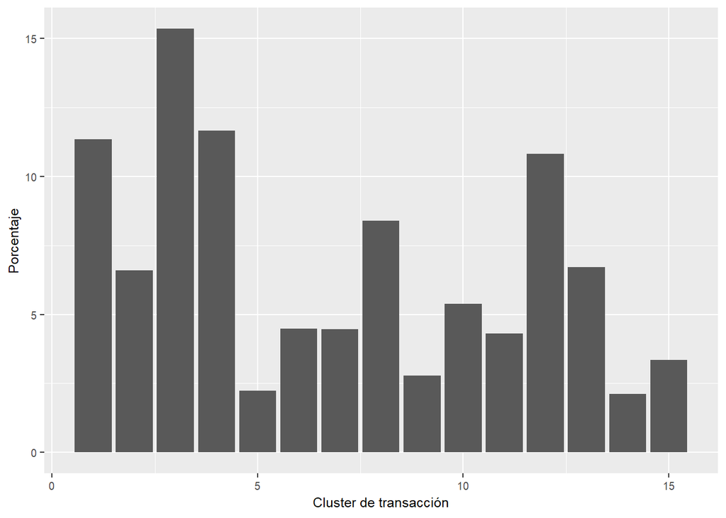

```r
## Grafico de barras con ggplot2
ggplot(dd, aes(x =cluster,y=(..count.. *100)/sum(..count..),fill=cluster)) + geom_bar()+ylab("Porcentaje")+xlab("Cluster de transacción")+theme(text = element_text(size=9.5))
```

## Conclusiones y Recomendaciones

1. Una recomendación en nuestros hallazgos, es el combinar la metodología de textming con clustes y LDA para obtener un mejor modelo de clasificación.
2. El modelo presentado en este informe no contempla la presencia de valores atípicos en las transacciones, por lo que de deben implementar algoritmos para que modelen las transacciones para valores extremos en la data.
3. Aún nos queda el pendiente el poder realizar una implementación que sea predictiva ante nuevas transacciones con entes nuevo que empleen PSE y que no se encuentran en la data.